# Analyzing tweets about Harry and Meghan on Oprah

### Load libraries

```r
library(rtweet)
library(tidyverse)
library(lubridate)
```

### Enter authentication information

You will need a Twitter developer account to do this. With that account you will have an appnam, consumer key, and consumer secret. Save those to the following objects.

```r
appname <- "namegoeshere"

key <- "apikeygoeshere"

apisecret <- "apisecretkeygoeshere"

token <- "accesstokengoeshere"

tokensecret <- "tokensecretgoeshere"
```

Using these objects you can now create a token that authenticates your access to Twitter data.

Running this code should open a new window in your browser which will indicate if the aunthentication was successful.

```r
twitter_token <- create_token(
  app = appname,
  consumer_key = key,
  consumer_secret = apisecret,
  access_token = token,
  access_secret = tokensecret
)
```

### Pull data on a specific hashtag

Let’s focuse on a recent event in the news – Meghan and Harry’s interview with Oprah

I’ll look at one hashtag: #HarryandMeghanonOprah

```r
interview <- search_tweets("#HarryandMeghanonOprah", n=18000, include_rts=FALSE)

## save as csv
## this way always working with same data, not re-pulling from twitter every time
write_as_csv(interview, "twitterinterviewdata.csv")
```

```r
interview <- read.csv("twitterinterviewdata.csv", header = T, stringsAsFactors = F)
```

### Let’s clean and tidy the data

```r
## Date and time tweet was sent
data <- interview %>%
  # separate the created_at column into a date and a time column
  separate(created_at, into = c("Date", "Time"), sep = " ", remove = F) %>%
  # using lubridate functions make Date and Time the correct formats
  mutate(Date = ymd(Date), Time = hms(Time))

## let's see what range of dates we have
range(data$Date)
```

```
## [1] "2021-03-08" "2021-03-14"
```

So we are looking at tweets from mar 8th until mar 14

```r
## confirm that each row is a unique tweet (or quote tweet)
data <- data %>%
  distinct(Date, Time, screen_name, text, .keep_all = T)
```

The language data is stored in 2 letter codes. Using this list (https://developer.twitter.com/en/docs/twitter-for-websites/supported-languages) I’m going to translate these codes to the full name of each language (where I’m able to).

```r
data$lang <- as.factor(data$lang)
head(unique(data$lang))
```

```
## [1] en  und de  es  pt  fr
## 35 Levels: ar cs cy da de el en es et fi fr hi ht hu in is it ja ko lt ... zh
```

```r
### write out full languages
data <- data %>%
  mutate(language = case_when(
    lang == "ar" ~ "Arabic",
    lang == "cs" ~ "Czech",
    lang == "cy" ~ "cy",
    lang == "da" ~ "Danish",
    lang == "de" ~ "German",
    lang == "el" ~ "Greek",
    lang == "en" ~ "English",
    lang == "es" ~ "Spanish",
    lang == "fr" ~ "French",
    lang == "hu" ~ "Hungarian",
    lang == "ht" ~ "ht",
    lang == "ko" ~ "Korean",
    lang == "in" ~ "Indonesian",
    lang == "it" ~ "Italian",
    lang == "ja" ~ "Japanese",
    lang == "nl" ~ "Dutch",
    lang == "pl" ~ "Polish",
    lang == "pt" ~ "Portuguese",
    lang == "tl" ~ "tl",
    lang == "ta" ~ "ta",
    lang == "und" ~ "Undetected",
    lang == "ht" ~ "ht",
    lang == "ca" ~ "ca",
    lang == "lt" ~ "lt",
    lang == "mr" ~ "mr",
    lang == "ro" ~ "Romanian",
    lang == "ru" ~ "Russian",
    lang == "tr" ~ "Turkish",
    lang == "zh" ~ "Chinese",
    lang == "is" ~ "is",
    lang == "sl" ~ "sl",
    lang == "fi" ~ "Finnish",
    lang == "cs" ~ "Czech",
    lang == "vi" ~ "Vietnamese",
    lang == "et" ~ "et",
    lang == "sv" ~ "Swedish",
    lang == "uk" ~ "Ukranian",
    lang == "hi" ~ "Hindi",
    lang == "fa" ~ "Persian",
    lang == "ne" ~ "ne",
    lang == "th" ~ "Thai",
    lang == "lv" ~ "lv",
    lang == "no" ~ "Norwegian",
    lang == "pa" ~ "pa",
    lang == "ru" ~ "Russian",
    lang == "te" ~ "te",
    lang == "si" ~ "si",
    lang == "ur" ~ "Urdu",
    lang == "gu" ~ "gu"
  ))
data$language <- as.factor(data$language)
head(unique(data$language))
```

```
## [1] English    Undetected German     Spanish    Portuguese French
## 35 Levels: Arabic Chinese cy Czech Danish Dutch English et Finnish ... Urdu
```

## Analyze the data on this hashtag

### When are people tweeting about this?

The interview aired March 7, 2021 in the evening (EST). According to this data, tweets with “#HarryandMeghanOnOprah” peaked 2 days later, on March 9. About 8000 tweets with that hastag were made on that day. March 8th had the second highest number of tweets (> 6000). Then there was a steep decline in the number of tweets to less than 2000 on March 10, and the tweets kept going down in number after that.

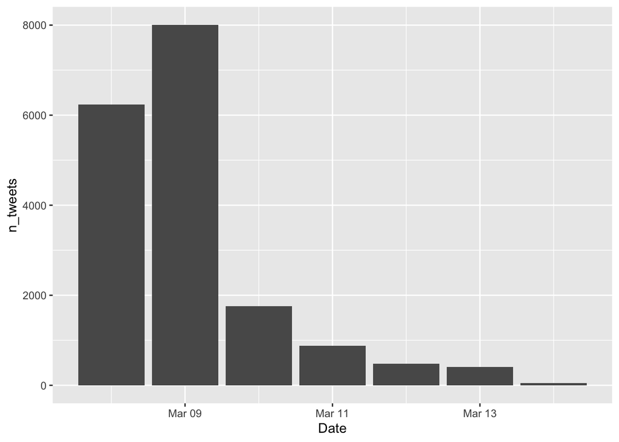

```r
freq_date <- data %>%
  ## want to know # of tweets in each language
  group_by(Date) %>%
  ## calculate summary variables
  summarise(n_tweets = n(), n_og_tweets = sum(is_quote == "FALSE"), n_quotes = sum(is_quote == "TRUE"))


ggplot(freq_date, aes(Date, n_tweets)) +
  geom_col()
```

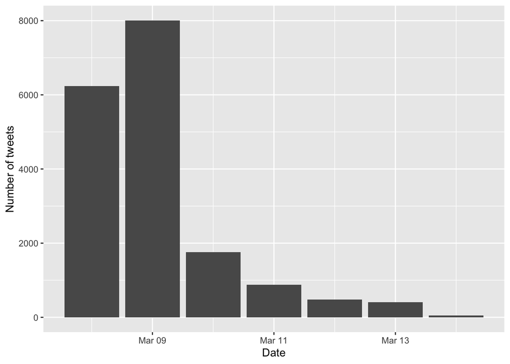

```r
## let's rename the axes on this graph
ggplot(freq_date, aes(Date, n_tweets)) +
  geom_col() +
  ylab("Number of tweets") +
  xlab("Date")
```

That is how to create the dataframe and plots yourself. But actually, there is a ggplot function that will do this for you, using the created_at column from the tweet data directly.

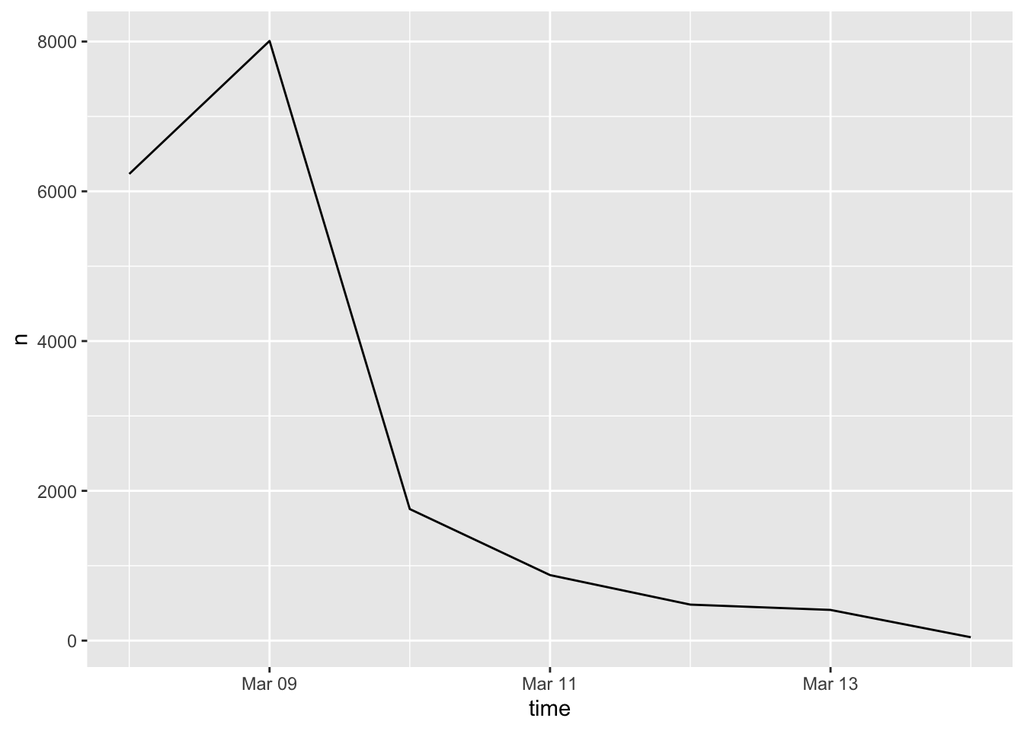

```r
## tweets by day
ts_plot(data, "days")
```

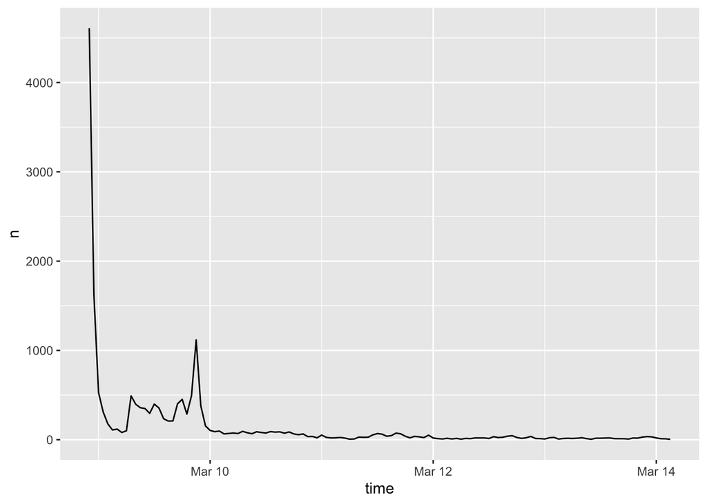

```r
## tweets by hour
ts_plot(data, "hours")
```

### In what languages are people tweeting?

By far the most tweets using this hashtag are in English. The second highest number of tweets are in Italian, then in undetected languages.

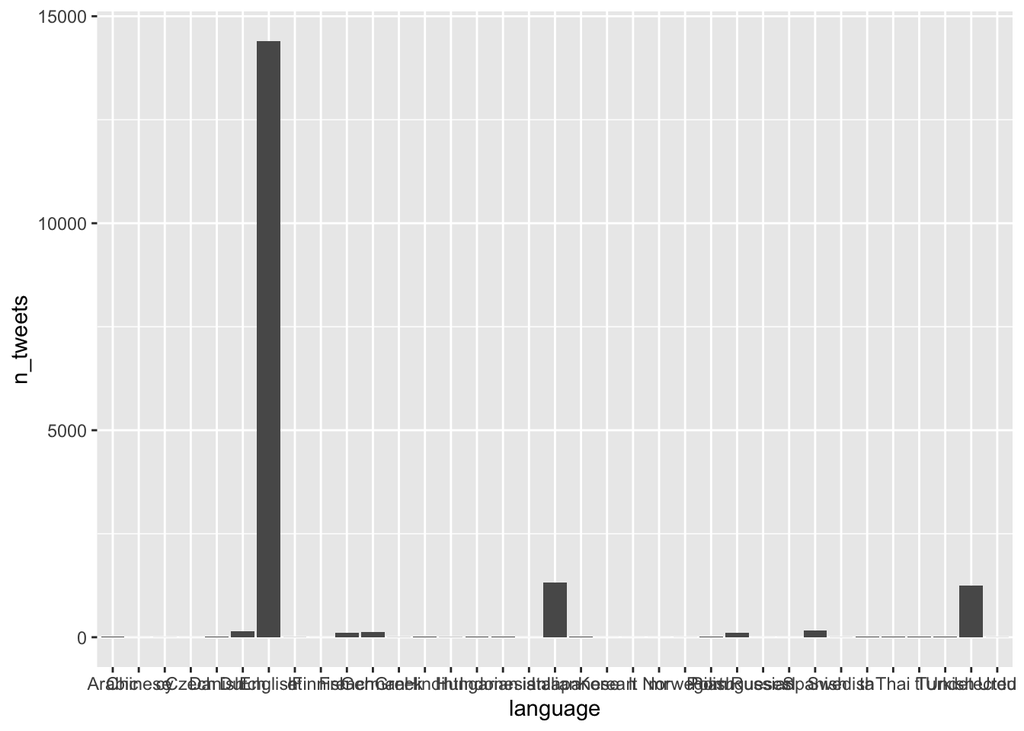

```r
freq_lang <- data %>%
  ## want to know # of tweets in each language
  group_by(language) %>%
  ## calculate summary variables
  summarise(n_tweets = n(), n_og_tweets = sum(is_quote == "FALSE"), n_quotes = sum(is_quote == "TRUE"))


ggplot(freq_lang, aes(language, n_tweets)) +
  geom_col()
```

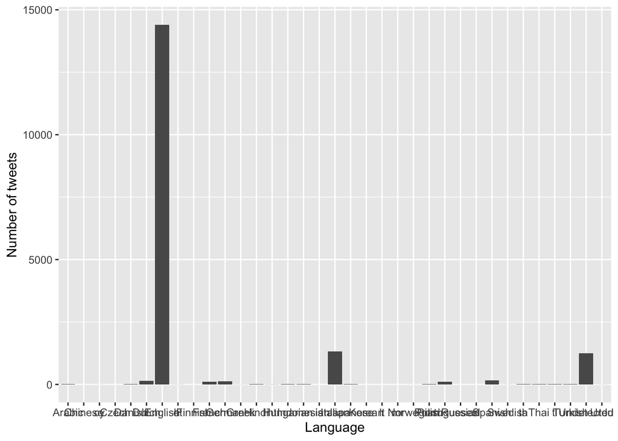

```r
## let's rename the axes
ggplot(freq_lang, aes(language, n_tweets)) +
  geom_col() +
  ylab("Number of tweets") +
  xlab("Language")
```

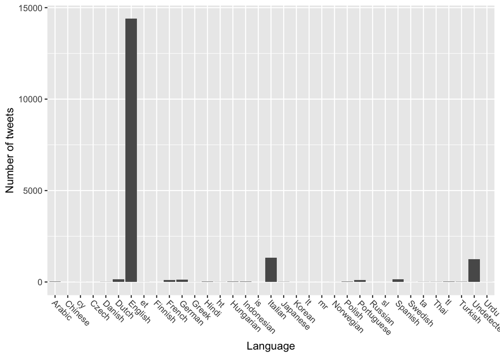

```r
## let's make the x tick labels more legible by changing the angle at which they're written
ggplot(freq_lang, aes(language, n_tweets)) +
  geom_col() +
  ylab("Number of tweets") +
  xlab("Language") +
  theme(axis.text.x = element_text(angle = -45, hjust = -.05))
```

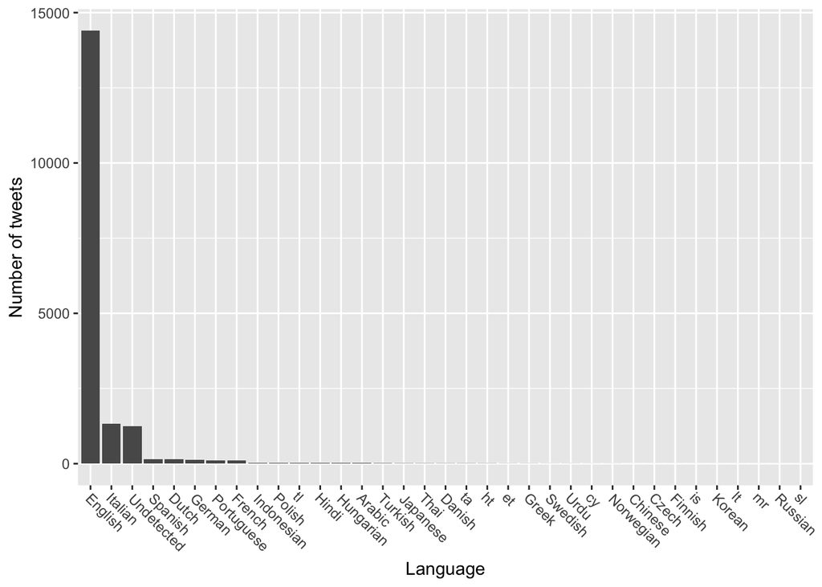

```r
## the languages are written in alphabetical order. let's order them by their y axis value
### there are a few ways to do this, but let's use dplyr functions
freq_lang <- freq_lang %>%
  # arrange in descending order
  arrange(desc(n_tweets)) %>%
  # update the factor levels
  mutate(language = factor(language, levels = language))
### now make the plot again
ggplot(freq_lang, aes(language, n_tweets)) +
  geom_col() +
  ylab("Number of tweets") +
  xlab("Language") +
  theme(axis.text.x = element_text(angle = -45, hjust = -.05))
```

The graph is very crowded because of all the languages. Let’s focus on the 10 most used languages in these tweets

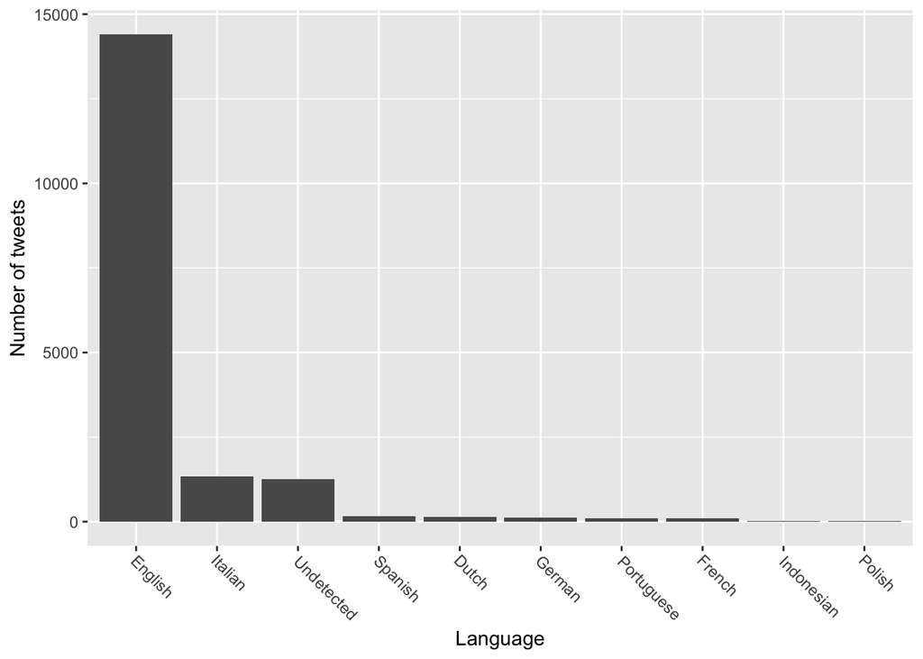

```r
## we already ordered the dataframe by  ntweets, so i'll select the first 10 rows
freq_lang_most <- freq_lang[1:10, ]

## and now make the same plot with this smaller dataset
ggplot(freq_lang_most, aes(language, n_tweets)) +
  geom_col() +
  ylab("Number of tweets") +
  xlab("Language") +
  theme(axis.text.x = element_text(angle = -45, hjust = -.05))
```

That’s better. but one value is much larger than the others. Let’s use facet_zoom from the ggforce package to show the original graph and another graph, zoomed in on the smaller values.

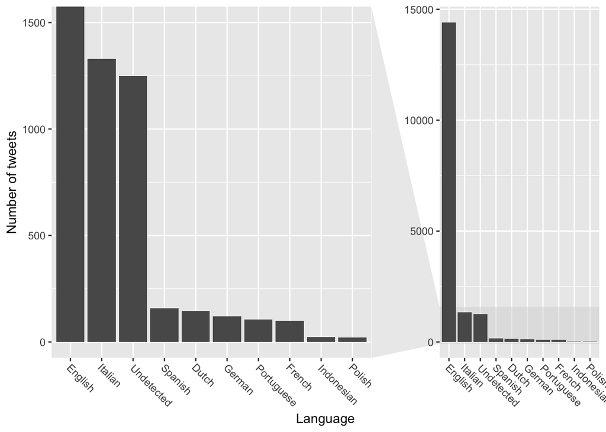

```r
library(ggforce)
ggplot(freq_lang_most, aes(language, n_tweets)) +
  geom_col() +
  ylab("Number of tweets") +
  xlab("Language") +
  theme(axis.text.x = element_text(angle = -45, hjust = -.05)) +
  facet_zoom(ylim = c(0, 1500))
```

```r
freq_lang_most$n_tweets[freq_lang_most$language == "Polish"]
```

```
## [1] 22
```

Now we can see much more clearly. Italian and undetected have over 1000 tweets. Spanish, Dutch, German, Portuguese and French have between 100 and 200 tweets. And Indonesian and Polish barely have any. In fact, we can look at the data and see that Polish has 22 tweets.

### Where are people tweeting from?

Well first, most people don’t have location data turned on for twitter. In fact, 17177 of these tweets do not have location data.

So, even though the data tells us that the most tweets came from Wandsworth, London, this isn’t very conclusive. That’s because 96% of the tweets don’t have location data!

```r
head(unique(data$place_full_name))
```

```
## [1] ""                   "St Petersburg, FL"  "Crayford, London"
## [4] "Aston, England"     "Rugby, England"     "Guildford, England"
```

```r
## how many tweets don't have a location
sum(data$place_full_name == "")
```

```
## [1] 17177
```

```r
loc <- data %>%
  ### lots of users turn off location data, so let's remove the blank locations
  filter(data$place_full_name != "") %>%
  count(place_full_name, sort = TRUE)

head(loc)
```

```
##          place_full_name  n
## 1     Wandsworth, London 14
## 2        Milan, Lombardy 11
## 3  Alessandria, Piedmont  9
## 4        London, England  9
## 5 Milton Keynes, England  9
## 6    Manchester, England  8
```

```r
## what proportion of tweets didn't show location data?
sum(data$place_full_name == "") / length(data$place_full_name)
```

```
## [1] 0.9645665
```

### How often are users tweeting about this?

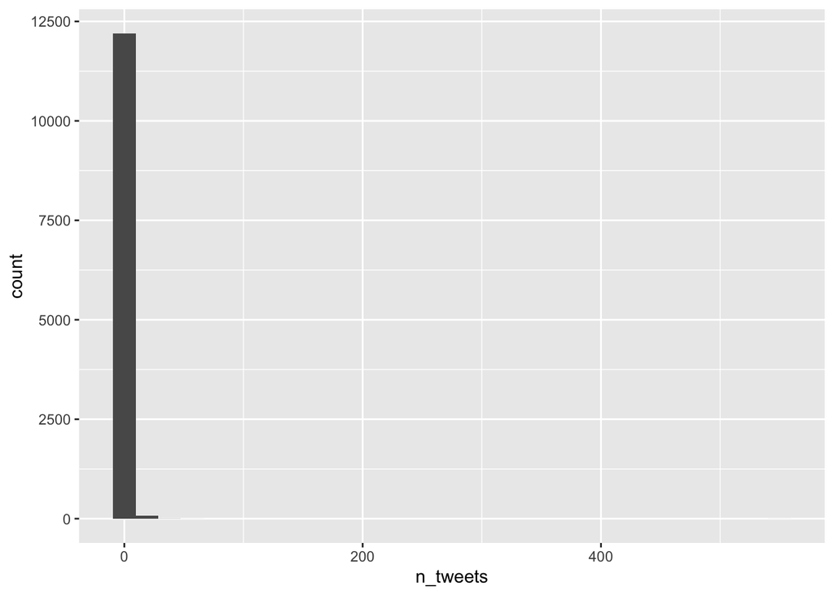

```r
freq_user <- data %>%
  ## want to know # of tweets per user
  group_by(user_id, language) %>%
  ## calculate summary variables
  summarise(n_tweets = n(), n_og_tweets = sum(is_quote == "FALSE"), n_quotes = sum(is_quote == "TRUE"))

## how often are individuals tweeting?
ggplot(freq_user) +
  geom_histogram(aes(n_tweets))
```

```r
## we can see how many individuals are tweeting once, twice, three times, etc.
## most are only tweeting once (10200). OBut one individual tweeted 551 times!
table(freq_user$n_tweets)
```

```
##
##     1     2     3     4     5     6     7     8     9    10    11    12    13
## 10200  1183   380   173   117    62    45    23    18    13    11     6    10
##    14    15    16    17    18    19    20    21    22    23    24    26    27
##     7     4     5     1     3     1     1     2     2     1     1     2     1
##    28    34    35    43    54   551
##     1     2     1     1     1     1
```

#### What languages are people tweeting in?

I’m going to use what we learned above to make the graph easier to read. I’ll arrange the languages in order of how many users used each language, focus on the most used languages, fix the axis labels, and use the zoom function.

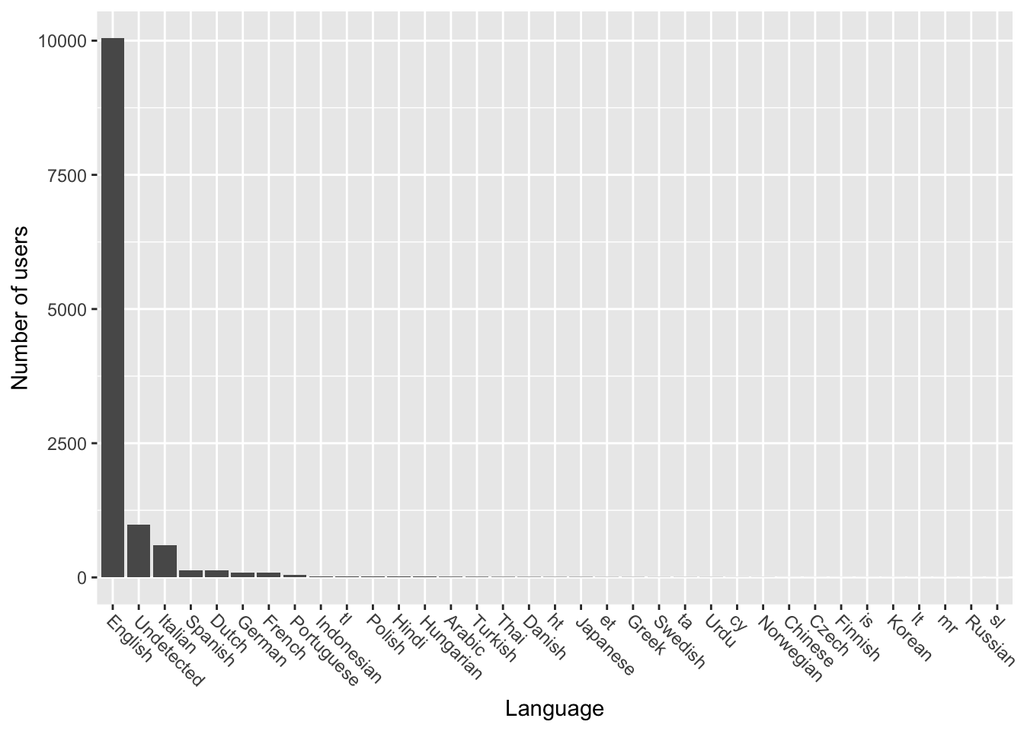

```r
## which languages have the most unique users
users_lang <- freq_user %>%
  group_by(language) %>%
  summarise(n_users = n(), n_tweets = sum(n_tweets))


users_lang <- users_lang %>%
  # arrange in descending order
  arrange(desc(n_users)) %>%
  # update the factor levels
  mutate(language = factor(language, levels = language))
### now make the plot
ggplot(users_lang, aes(language, n_users)) +
  geom_col() +
  ylab("Number of users") +
  xlab("Language") +
  theme(axis.text.x = element_text(angle = -45, hjust = -.05))
```

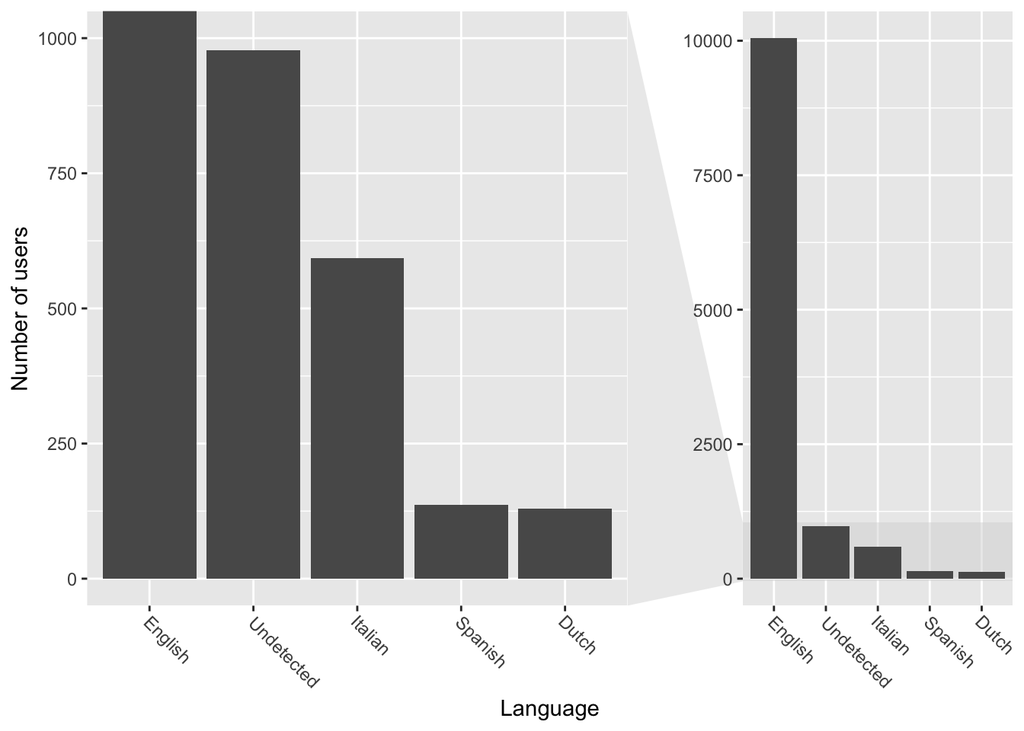

```r
## pretty good, but let's focus on the top 5 languages
lang_most_users <- users_lang[1:5, ]
ggplot(lang_most_users, aes(language, n_users)) +
  geom_col() +
  ylab("Number of users") +
  xlab("Language") +
  theme(axis.text.x = element_text(angle = -45, hjust = -.05)) +
  facet_zoom(ylim = c(0,1000))
```

### What are the most common hashtags used in the same tweets?

A few notes: I don’t want to consider hashtags directly related to the interview (e.g. meghanandharryonoprah, meghanharryoprah, ) because that is essentially how I pulled these tweets from twitter.

```r
head(data$hashtags)
```

```
## [1] "MeghanMarkle woke wokeism TriggerWarning WokeSupremacy racism RoyalFamily HarryandMeghanonOprah"
## [2] "HarryandMeghanonOprah"
## [3] "HarryandMeghanonOprah"
## [4] "meghan HarryandMeghanonOprah"
## [5] "HarryandMeghanonOprah HarryandMeghan"
## [6] "HarryandMeghanonOprah"
```

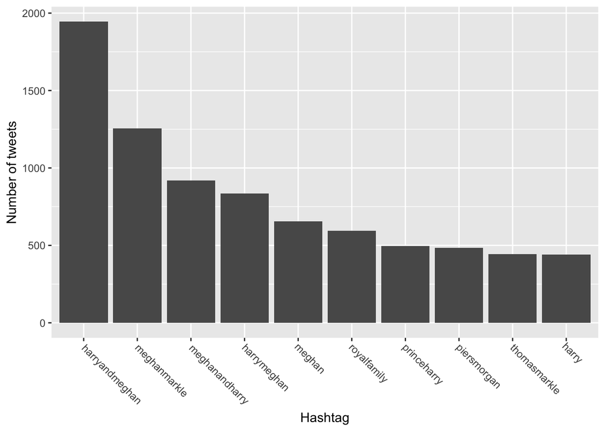

```r
## first we need to separate these character strings into each individual hashtag (at the space)
## create a list of character vectors by splitting at the space
data$hashtags <- str_split(data$hashtags, " ")

## now we will unlist these - making each unique hashtag a separate row
hashtags <- unlist(data$hashtags)

hashtags_data <- as.data.frame(hashtags)
## in order for all hashtags (multiple hashtags in one tweet) to be a separate data point, need to do this from the rtweet data (not from the saved csv)
## so I will save this hashtag data as a csv now
write.csv(hashtags_data, "hashtags_data_all.csv", row.names = F)

hashtags_all <- hashtags_data %>%
  ## make all lowercase
  mutate(hashtags = tolower(hashtags))

## find the number of times each hashtag is used
hashtags_group <- hashtags_all %>%
  group_by(hashtags) %>%
  summarise(n_tweets = n()) %>%
  ## I don't want to include hashtags directly related to the interview, since that is how I pulled these tweets from twitter in the first place
  filter(!(hashtags %in% c("harryandmeghanonoprah", "meghanandharryonoprah", "oprahmeghanharry")))


## get the top 10 hashtags
hashtags_most <- hashtags_group %>%
  arrange(desc(n_tweets)) %>%
  mutate(hashtags = factor(hashtags, levels = hashtags))
hashtags_most <- hashtags_most[1:10, ]

ggplot(hashtags_most, aes(hashtags, n_tweets)) +
  geom_col() +
  xlab("Hashtag") +
  ylab("Number of tweets") +
  theme(axis.text.x = element_text(angle = -45, hjust = -.05))
```

A lot of these hashtags are just names of the individuals involved (e.g. harry, princeharry, meghan, meghanmarkle) and I don’t care about that either. Let’s remove those to get a better sense of the other topics connected to the interview

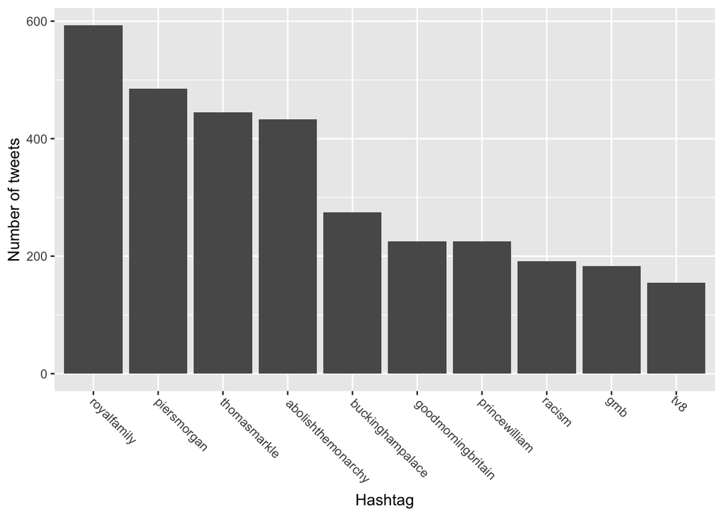

```r
hashtags_group <- hashtags_group %>%
  filter(!grepl("harry", hashtags_group$hashtags))
hashtags_group <- hashtags_group %>%
  filter(!grepl("meghan", hashtags_group$hashtags))
hashtags_group <- hashtags_group %>%
  filter(!grepl("oprah", hashtags_group$hashtags))

hashtags_most2 <- hashtags_group %>%
  arrange(desc(n_tweets)) %>%
  mutate(hashtags = factor(hashtags, levels = hashtags))
hashtags_most2 <- hashtags_most2[1:10, ]

ggplot(hashtags_most2, aes(hashtags, n_tweets)) +
  geom_col() +
  xlab("Hashtag") +
  ylab("Number of tweets") +
  theme(axis.text.x = element_text(angle = -45, hjust = -.05))
```

This is much more interesting instead of just seeing the three people’s names involved in the interview We will continue excluding those hashtags that contain their names for the remainder of these analyses.

Now that graph shows the top 10 hashtags over the last week.

### How did the accompanying hashtags change as the days passed?

To compare across days, I won’t look at the number of tweets containing each hashtag. But the proportion of tweets on that day that contain each hashtag. Since the total number of tweets changes each day.

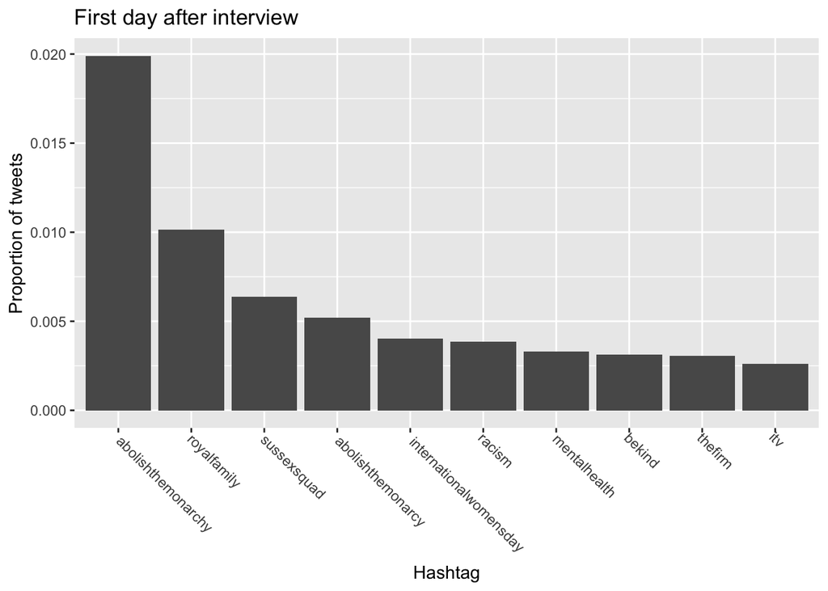

```r
## a few ways to do this
### I'll use a simple one by creating different datasets for each date

#### FIRST DAY
firstday <- data %>%
  filter(Date == ymd("20210308"))

firstdayhash <- unlist(firstday$hashtags)

firstdayhash_data <- as.data.frame(firstdayhash)

firstdayhash_data <- firstdayhash_data %>%
  rename(hashtags = firstdayhash) %>%
  ## make all lowercase
  mutate(hashtags = tolower(hashtags))

## To compare across days, I'll look at the proportion of tweets that use each hashtag, not the number

firstday_group <- firstdayhash_data %>%
  group_by(hashtags) %>%
  summarise(prop_tweets = n() / nrow(firstdayhash_data), n_tweets = n()) %>%
  filter(!(hashtags %in% c("harryandmeghanonoprah", "meghanandharryonoprah", "oprahmeghanharry")))

## Again, I don't want to consider hashtags just about harry meghan and oprah
firstday_group <- firstday_group %>%
  filter(!grepl("harry", firstday_group$hashtags))
firstday_group <- firstday_group %>%
  filter(!grepl("meghan", firstday_group$hashtags))
firstday_group <- firstday_group %>%
  filter(!grepl("oprah", firstday_group$hashtags))

## top 10 hashtags
firstday_most <- firstday_group %>%
  arrange(desc(prop_tweets)) %>%
  mutate(hashtags = factor(hashtags, levels = hashtags))
firstday_most <- firstday_most[1:10, ]

ggplot(firstday_most, aes(hashtags, prop_tweets)) +
  geom_col() +
  xlab("Hashtag") +
  ylab("Proportion of tweets") +
  theme(axis.text.x = element_text(angle = -45, hjust = -.05)) +
  ggtitle("First day after interview")
```

I use the same code to get datasets for days 2 - 7, but I won’t show that here. Just the graphs.

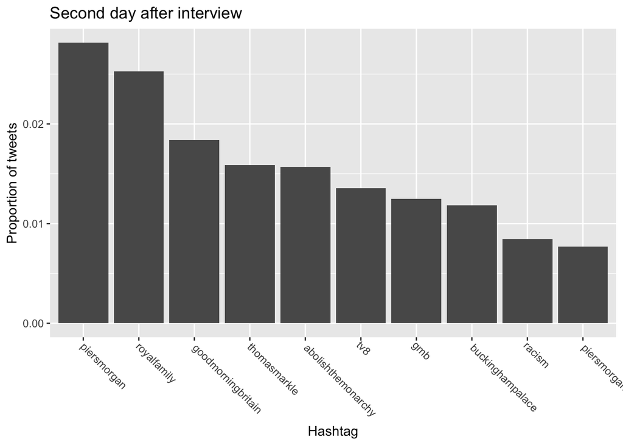

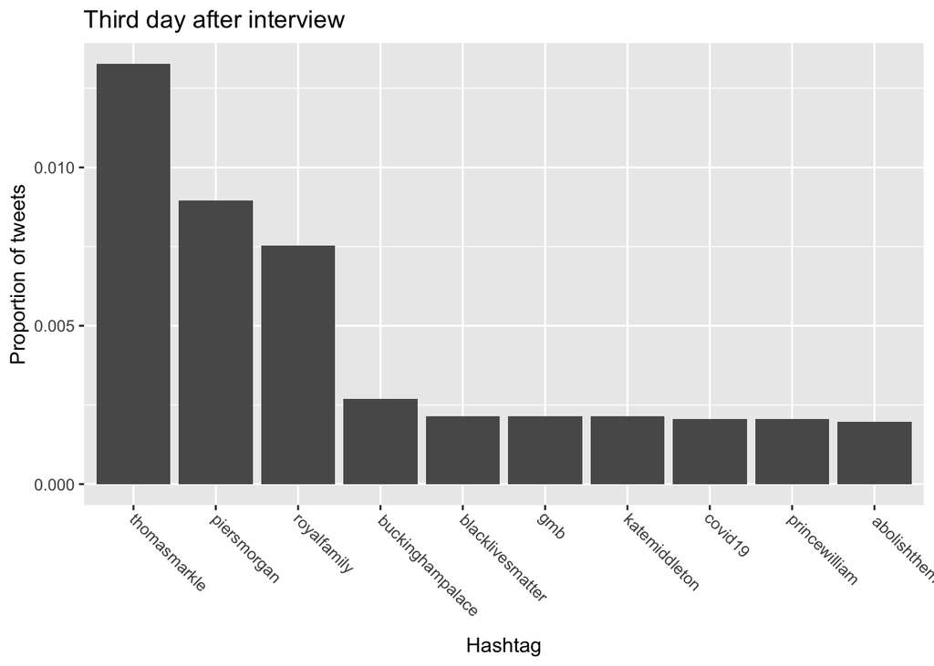

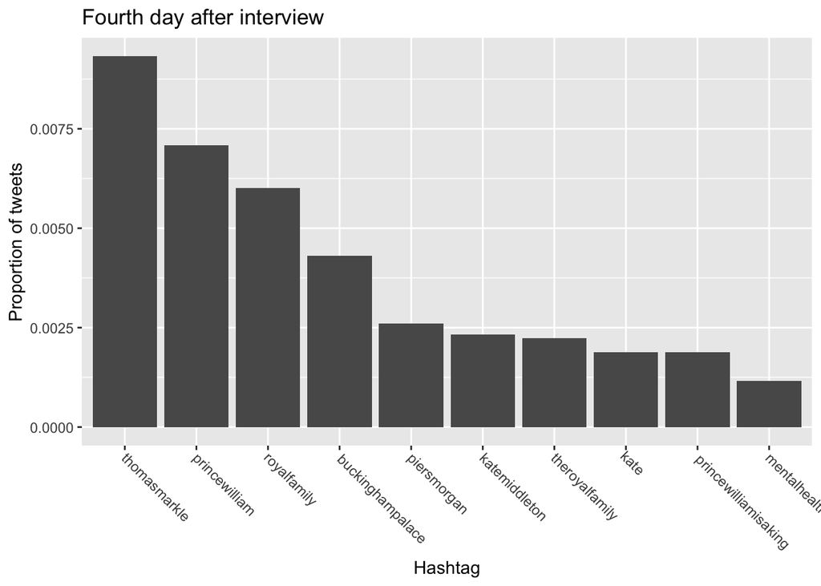

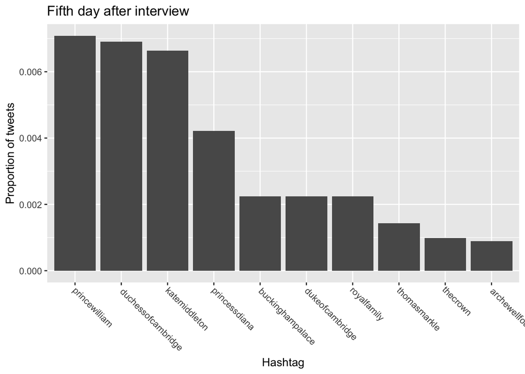

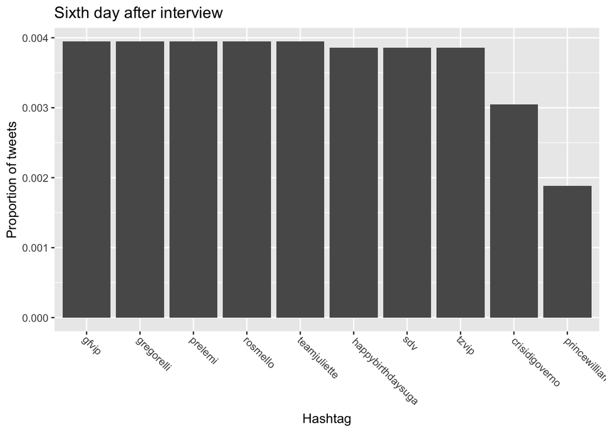

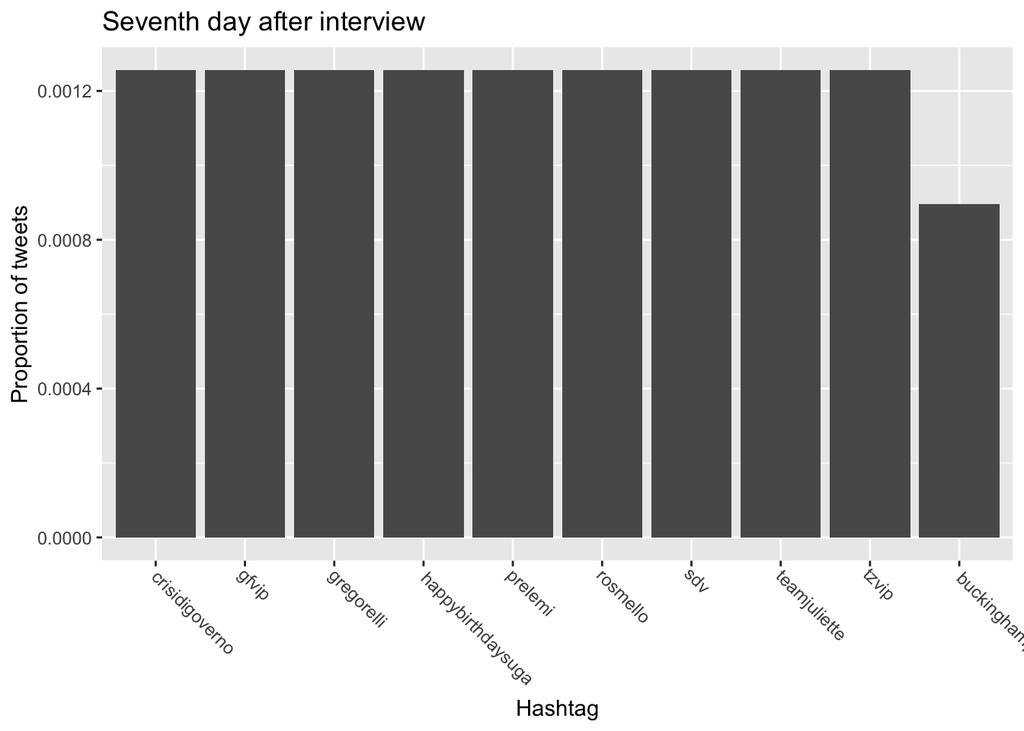

Let’s combine these datasets to create a graph showing the change in the proportion of tweets using these hashtags across time.

```r
## add a column to each dataset indicating which day it is
seventhday_most2 <- seventhday_most %>%
  mutate(Day = 7)
sixthday_most2 <- sixthday_most %>%
  mutate(Day = 6)
fifthday_most2 <- fifthday_most %>%
  mutate(Day = 5)
fourthday_most2 <- fourthday_most %>%
  mutate(Day = 4)
thirdday_most2 <- thirdday_most %>%
  mutate(Day = 3)
secondday_most2 <- secondday_most %>%
  mutate(Day = 2)
firstday_most2 <- firstday_most %>%
  mutate(Day = 1)

alldays_most <- rbind(firstday_most2, secondday_most2, thirdday_most2, fourthday_most2, fifthday_most2, sixthday_most2, seventhday_most2)
alldays_most$Day <- as.factor(alldays_most$Day)
```

Let’s focus at the hashtags that appear across the most days.

#### How many days does each hashtag appear in?

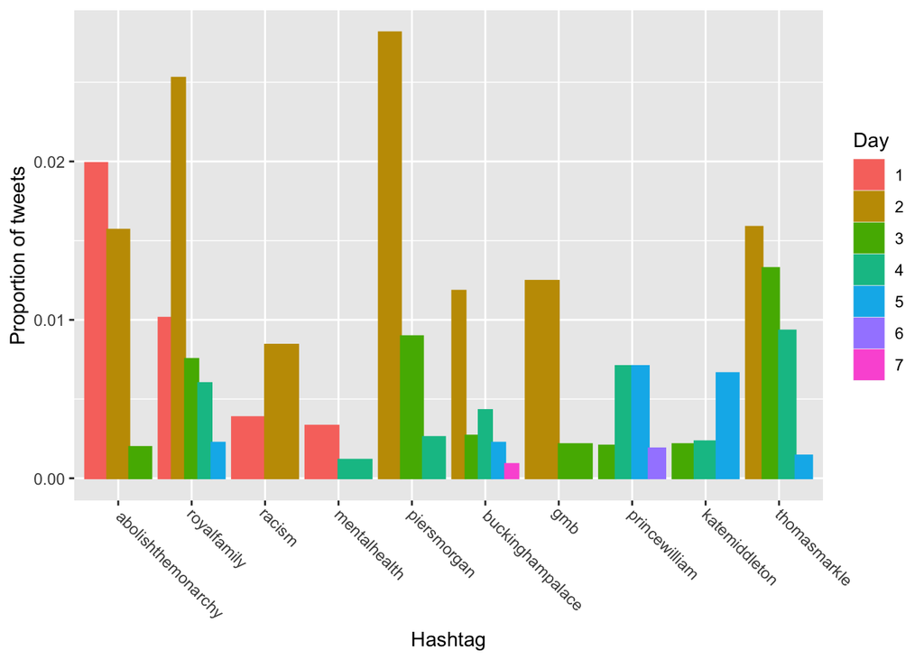

```r
alldays_ndays <- alldays_most %>%
  group_by(hashtags) %>%
  summarise(n_days = n())

### let's look at the top 10
alldays_ndays <- alldays_ndays %>%
  arrange(desc(n_days))
alldays_ndays <- alldays_ndays[1:10, ]

### use only these hashtags for the graph
alldays_top <- left_join(alldays_ndays, alldays_most)
ggplot(alldays_top, aes(hashtags, prop_tweets)) +
  geom_col(aes(col = Day, fill = Day), position = "dodge") +
  xlab("Hashtag") +
  ylab("Proportion of tweets") +
  theme(axis.text.x = element_text(angle = -45, hjust = -.05))
```

We can make this a bit prettier and easier to read by plotting the changes in prop across days for each hashtag separately

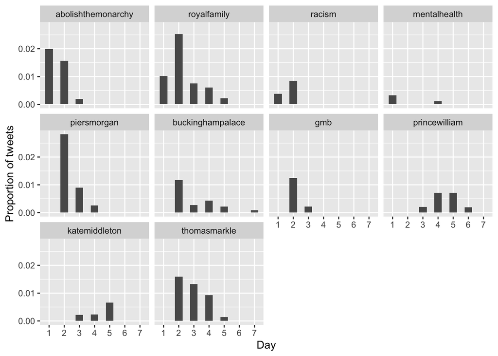

```r
ggplot(alldays_top, aes(Day, prop_tweets)) +
  geom_col(width = 0.5, position = position_dodge(0.7)) +
  ylab("Proportion of tweets") +
  facet_wrap(alldays_top$hashtags)
```

This shows us to see how the popularity of these hashtags changed across time. For example, in the 2 days following the interview “#abolishthemonarchy” was frequently used. But stopped being used after day 3. “#royalfamily” peaked on day 2 and then went down in use. Meanwhile “#princewilliam” and “#katemiddleton” did not start being used until day 3. They went up on days 4 and 5 and then back down. #racism peaked on day 2 but was not used after that. And #mentalhealth peaked on day 1 and reappeared on day 4.